# Faraway_ch6

Harry Woo

2020 5 26

## Faraway Chapter 6 Diagnostics

### Problem 1

*Using the sat dataset, fit a model with the total SAT score as the response and expend, salary, ratio and takers as predictors. Perform regression diagnostics on this model to answer the following questions. Display any plots that are relevant. Do not provide any plots about which you have nothing to say. Suggest possible improvements or corrections to the model where appropriate.*

```r
library(faraway)
library(ggplot2)
library(GGally)
library(dplyr)
library(knitr)
library(MASS)
library(car)
library(tibble)
library(gridExtra)
```

```r
data("sat")
head(sat)
```

```
##            expend ratio salary takers verbal math total
## Alabama     4.405  17.2 31.144      8    491  538  1029
## Alaska      8.963  17.6 47.951     47    445  489   934
## Arizona     4.778  19.3 32.175     27    448  496   944
## Arkansas    4.459  17.1 28.934      6    482  523  1005
## California  4.992  24.0 41.078     45    417  485   902
## Colorado    5.443  18.4 34.571     29    462  518   980
```

```r
str(sat)
```

```
## 'data.frame':    50 obs. of  7 variables:
##  $ expend: num  4.41 8.96 4.78 4.46 4.99 ...
##  $ ratio : num  17.2 17.6 19.3 17.1 24 18.4 14.4 16.6 19.1 16.3 ...
##  $ salary: num  31.1 48 32.2 28.9 41.1 ...
##  $ takers: int  8 47 27 6 45 29 81 68 48 65 ...
##  $ verbal: int  491 445 448 482 417 462 431 429 420 406 ...
##  $ math  : int  538 489 496 523 485 518 477 468 469 448 ...
##  $ total : int  1029 934 944 1005 902 980 908 897 889 854 ...
```

```r
summary(sat)
```

```
##      expend          ratio           salary          takers
##  Min.   :3.656   Min.   :13.80   Min.   :25.99   Min.   : 4.00
##  1st Qu.:4.882   1st Qu.:15.22   1st Qu.:30.98   1st Qu.: 9.00
##  Median :5.768   Median :16.60   Median :33.29   Median :28.00
##  Mean   :5.905   Mean   :16.86   Mean   :34.83   Mean   :35.24
##  3rd Qu.:6.434   3rd Qu.:17.57   3rd Qu.:38.55   3rd Qu.:63.00
##  Max.   :9.774   Max.   :24.30   Max.   :50.05   Max.   :81.00
##      verbal           math           total
##  Min.   :401.0   Min.   :443.0   Min.   : 844.0
##  1st Qu.:427.2   1st Qu.:474.8   1st Qu.: 897.2
##  Median :448.0   Median :497.5   Median : 945.5
##  Mean   :457.1   Mean   :508.8   Mean   : 965.9
##  3rd Qu.:490.2   3rd Qu.:539.5   3rd Qu.:1032.0
##  Max.   :516.0   Max.   :592.0   Max.   :1107.0
```

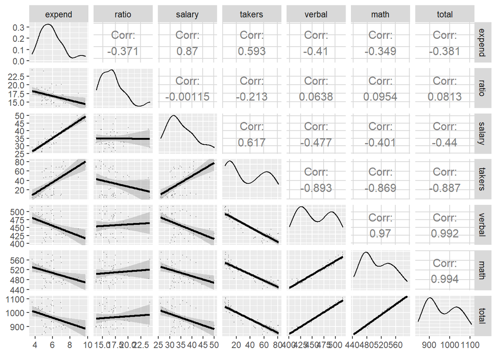

```r
ggpairs(sat,
        lower = list(continuous = wrap("smooth", alpha = 0.3, size = 0.1)),
        diag = list(discrete="barDiag",
                    continuous = wrap("densityDiag", alpha = 0.5 )),
        upper = list(combo = wrap("box_no_facet", alpha = 0.5),
                            continuous = wrap("cor", size = 4,
                                              alignPercent = 0.8))) +
  theme(legend.position = "bottom")
```

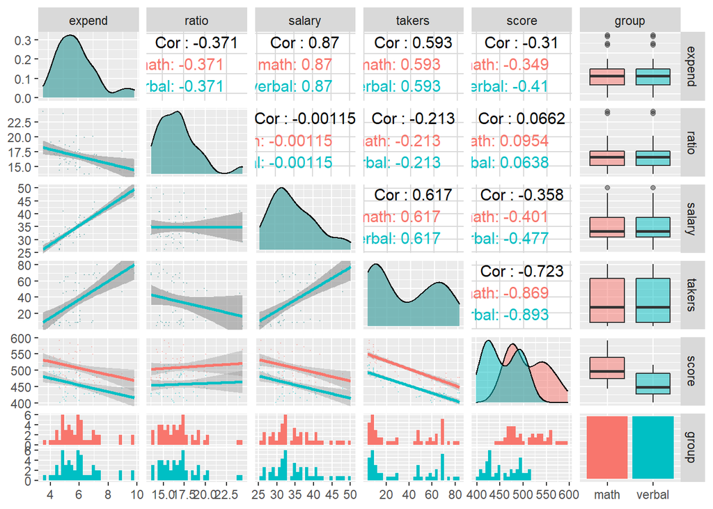

```r
sat_math <- sat %>%
  dplyr::select(-c("verbal", "total")) %>%
  rename(score = math) %>%
  mutate(group = "math")

sat_verbal <- sat %>%
  dplyr::select(-c("math", "total")) %>%
  rename(score = verbal) %>%
  mutate(group = "verbal")

sat2 <- rbind(sat_math, sat_verbal)

ggpairs(sat2, aes(colour = group),
        lower = list(continuous = wrap("smooth", alpha = 0.3, size = 0.1)),
        diag = list(discrete="barDiag",
                    continuous = wrap("densityDiag", alpha = 0.5 )),
        upper = list(combo = wrap("box_no_facet", alpha = 0.5),
                            continuous = wrap("cor", size = 4,
                                              alignPercent = 0.8))) +
  theme(legend.position = "bottom")
```

#### Model Fitting

문제에서 요구한 바와 같이 `total`을 종속변수로, 다른 변수를 설명변수로 하여 회귀모형 `sat_lm`을 적합하였다. 전체 모형의 결정계수는 0.825 수준에 p-value는 유의수준 0.05에서 매우 유의하다. 회귀계수 중 `takers`만 통계적으로 유의수준 0.05에서 유의한 것으로 나타난다.

```r
sat_lm <- lm(total ~ expend + salary + ratio + takers, data = sat)
summary(sat_lm)
```

```
##
## Call:
## lm(formula = total ~ expend + salary + ratio + takers, data = sat)
##
## Residuals:
##     Min      1Q  Median      3Q     Max
## -90.531 -20.855  -1.746  15.979  66.571
##
## Coefficients:
##              Estimate Std. Error t value Pr(>|t|)
## (Intercept) 1045.9715    52.8698  19.784  < 2e-16 ***
## expend         4.4626    10.5465   0.423    0.674
## salary         1.6379     2.3872   0.686    0.496
## ratio         -3.6242     3.2154  -1.127    0.266
## takers        -2.9045     0.2313 -12.559 2.61e-16 ***
## ---
## Signif. codes:  0 '***' 0.001 '**' 0.01 '*' 0.05 '.' 0.1 ' ' 1
##
## Residual standard error: 32.7 on 45 degrees of freedom
## Multiple R-squared:  0.8246, Adjusted R-squared:  0.809
## F-statistic: 52.88 on 4 and 45 DF,  p-value: < 2.2e-16
```

#### (a) Check the constant variance assumption for the errors.

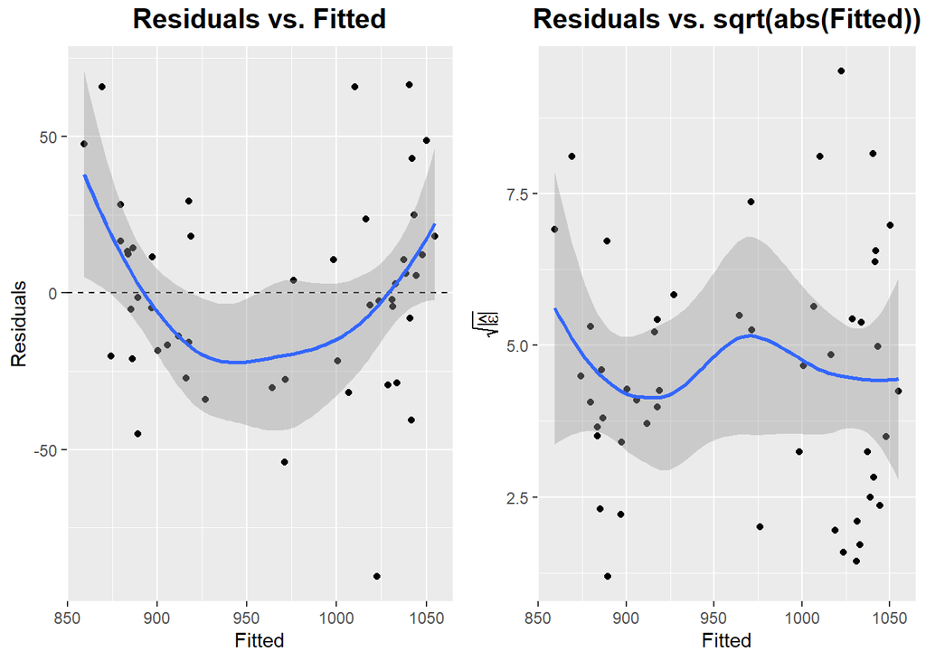

```r
#par(mfrow = c(1, 2))
#plot(sat_lm, which = 1)
#plot(sat_lm, which = 3)

diag1 <- ggplot(data = sat_lm, aes(x = .fitted, y = .resid)) +
  geom_point() + geom_hline(yintercept = 0, linetype = 2) +
  geom_smooth(method = "loess") +
  xlab("Fitted") + ylab("Residuals") +
  ggtitle(label = "Residuals vs. Fitted") +
  theme(plot.title = element_text(size = 15, hjust = 0.5, vjust = 1.5, face = "bold"))

diag2 <- ggplot(data = sat_lm, aes(x = .fitted, y = sqrt(abs(.resid)))) +
  geom_point() + geom_smooth(method = "loess") +
  xlab("Fitted") + ylab(expression(sqrt(abs(hat(epsilon))))) +
  ggtitle(label = "Residuals vs. sqrt(abs(Fitted))") +
  theme(plot.title = element_text(size = 15, hjust = 0.5, vjust = 1.5, face = "bold"))

grid.arrange(diag1, diag2, ncol = 2)
```

잔차와 추정치 사이의 관계를 산점도로 표현하여 검토한 결과, 잔차의 약한 비선형성이 관측되며, 950점을 전후로 두 그룹으로 분포가 나뉘어 등분산성에 문제가 있을 수 있는 것으로 보인다. 그러나 두 번째 plot인 $\sqrt{|\hat{\epsilon}|}$과 추정치 간의 관계에서는 등분산성에 큰 문제가 없는 것으로 관측된다.

```r
summary(lm(abs(residuals(sat_lm)) ~ fitted(sat_lm)))
```

```
##
## Call:
## lm(formula = abs(residuals(sat_lm)) ~ fitted(sat_lm))
##
## Residuals:
##     Min      1Q  Median      3Q     Max
## -22.827 -14.323  -5.001   6.204  65.754
##
## Coefficients:
##                Estimate Std. Error t value Pr(>|t|)
## (Intercept)    10.60384   40.82315   0.260    0.796
## fitted(sat_lm)  0.01386    0.04216   0.329    0.744
##
## Residual standard error: 20.05 on 48 degrees of freedom
## Multiple R-squared:  0.002247,   Adjusted R-squared:  -0.01854
## F-statistic: 0.1081 on 1 and 48 DF,  p-value: 0.7438
```

```r
summary(lm(sqrt(abs(residuals(sat_lm))) ~ fitted(sat_lm)))
```

```
##
## Call:
## lm(formula = sqrt(abs(residuals(sat_lm))) ~ fitted(sat_lm))
##
## Residuals:
##     Min      1Q  Median      3Q     Max
## -3.3097 -1.2366 -0.2234  0.9929  5.0337
##
## Coefficients:
##                  Estimate Std. Error t value Pr(>|t|)
## (Intercept)     4.6484524  4.0660807   1.143    0.259
## fitted(sat_lm) -0.0001637  0.0041994  -0.039    0.969
##
## Residual standard error: 1.997 on 48 degrees of freedom
## Multiple R-squared:  3.166e-05,  Adjusted R-squared:  -0.0208
## F-statistic: 0.00152 on 1 and 48 DF,  p-value: 0.9691
```

잔차의 절대값 및 제곱근과 추정치 간의 관계를 분석한 결과, p-value 가 모두 매우 높아 등분산성 가정을 기각할 수 없다.

```r
var.test(residuals(sat_lm)[fitted(sat_lm) >= 950],
         residuals(sat_lm)[fitted(sat_lm) < 950])
```

```
##
##  F test to compare two variances
##
## data:  residuals(sat_lm)[fitted(sat_lm) >= 950] and residuals(sat_lm)[fitted(sat_lm) < 950]
## F = 1.651, num df = 27, denom df = 21, p-value = 0.2419
## alternative hypothesis: true ratio of variances is not equal to 1
## 95 percent confidence interval:
##  0.7071032 3.6928150
## sample estimates:
## ratio of variances
##            1.65098
```

```r
ncvTest(sat_lm)
```

```
## Non-constant Variance Score Test
## Variance formula: ~ fitted.values
## Chisquare = 0.6972119, Df = 1, p = 0.40372
```

첫 번째 plot에서 관측된 집단화 가능성과 관련하여, 950점을 전후로 잔차를 두 그룹으로 나누어 F test를 진행한 결과, p-value가 0.24로 등분산성 가정을 기각할 수 없다. 위의 분석에 따라 `sat` 데이터에는 non-constant variance 이슈가 있다고 할 수 없는 것으로 판단된다.

추가로 `car` 패키지의 `ncvTest` 함수를 통해서도 검토한 결과, p = 0.40 으로 등분산성 가정을 기각할 수 없다.

#### (b) Check the normality assumption.

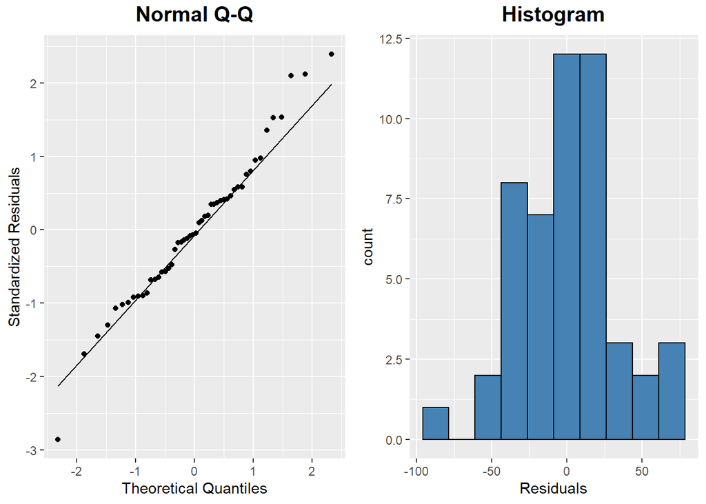

```r
#plot(sat_lm, which = 2)

diag3 <- ggplot(data = sat_lm, aes(sample = .stdresid)) +
  stat_qq() + stat_qq_line() +
  xlab("Theoretical Quantiles") + ylab("Standardized Residuals") +
  ggtitle(label = "Normal Q-Q") +
  theme(plot.title = element_text(size = 15, hjust = 0.5, vjust = 1.5, face = "bold"))

diag4 <- ggplot(data = sat_lm, aes(x = .resid)) +
  geom_histogram(bins = 10, fill = "steelblue", colour = "black") +
  xlab("Residuals") + ggtitle(label = "Histogram") +
  theme(plot.title = element_text(size = 15, hjust = 0.5, vjust = 1.5, face = "bold"))

grid.arrange(diag3, diag4, ncol = 2)
```

정규성 검토를 위하여 Normal Q-Q plot을 검토한 결과, 거의 직선형태의 분포가 관측되었으며, 우상단에서 일부 직선을 벗어나는 값이 관측되나 정규성을 기각할 증거는 없는 것으로 판단된다. 잔차의 히스토그램 또한 종 형태에 가까운 모양이 관측되며 정규성 가정을 뒷받침하고 있는 것으로 보인다.

```r
shapiro.test(sat_lm$residuals)
```

```
##
##  Shapiro-Wilk normality test
##
## data:  sat_lm$residuals
## W = 0.97691, p-value = 0.4304
```

Shapiro-Wilk’s Test 실시 결과 $p-value = 0.43 > 0.05$ 으로, 잔차의 정규성 가정(귀무가설)을 기각하지 못한다.

#### (c) Check for large leverage points.

```r
sat_hatv <- hatvalues(sat_lm)
head(sat_hatv)
```

```
##    Alabama     Alaska    Arizona   Arkansas California   Colorado
## 0.09537668 0.18030612 0.04931612 0.05382878 0.28211791 0.03014533
```

```r
sum(sat_hatv)
```

```
## [1] 5
```

`hatvalues`를 통해 leverage를 `sat_hatv`로 생성하였다. 일반적으로 large leverage는 $2p/n$인 지점을 나타내고, `p = sum(sat_hatv)` 이므로, 간단히 large leverage point를 추려보면 다음과 같다.

```r
sat_large <- 2 * sum(sat_hatv) / length(sat_lm$fitted.values)

sat %>%
  rownames_to_column() %>% rename(state = rowname) %>%
  mutate(hatv = hatvalues(sat_lm)) %>%
  filter(hatv > sat_large) %>%
  arrange(desc(hatv))
```

```
##         state expend ratio salary takers verbal math total      hatv
## 1        Utah  3.656  24.3 29.082      4    513  563  1076 0.2921128
## 2  California  4.992  24.0 41.078     45    417  485   902 0.2821179
## 3 Connecticut  8.817  14.4 50.045     81    431  477   908 0.2254519
## 4  New Jersey  9.774  13.8 46.087     70    420  478   898 0.2220978
```

위의 4개 주가 large leverage points로 추정된다.

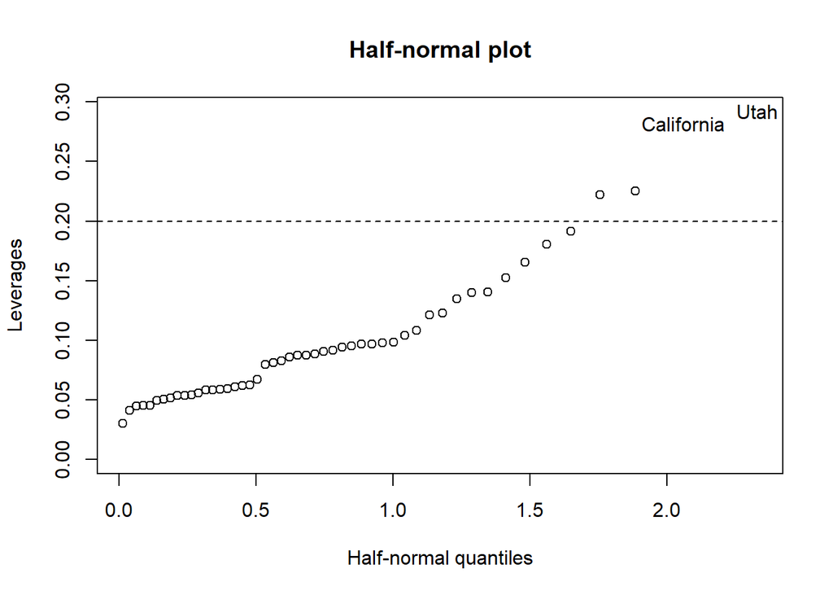

```r
sat_states <- row.names(sat)
halfnorm(sat_hatv, labs = sat_states, ylab = "Leverages")
abline(h = (2 * sum(sat_hatv) / length(sat_lm$fitted.values)), lty = 2)
title(main = "Half-normal plot")
```

Half-normal plot을 통해 확인한 결과, Utah와 California가 명확히 Large leverage로 확인되며, Connecticut과 New Jersey는 large leverage로 분류할 수 있으나 그 정도는 상대적으로 낮은 것으로 보인다.

#### (d) Check for outliers.

```r
set.seed(123)
sat_stud <- rstudent(sat_lm)

sat_stud2 <- as.data.frame(sat_stud) %>%
  rownames_to_column() %>% rename(state = rowname) %>%
  rename(stdresid = sat_stud)
```

Bonferroni correction을 통한 outlier 확인을 위해 스튜던트 잔차를 `sat_stud2` 라는 데이터프레임으로 생성하였다.

```r
sat_stud2 %>% arrange(stdresid) %>% head(3)
```

```
##            state  stdresid
## 1  West Virginia -3.124428
## 2         Nevada -1.732004
## 3 South Carolina -1.468832
```

```r
sat_stud2 %>% arrange(stdresid) %>% tail(3)
```

```
##            state stdresid
## 48 New Hampshire 2.190006
## 49  North Dakota 2.213686
## 50          Utah 2.529587
```

```r
#Bonferroni critical value
sat_bcv <- qt(0.05 / (50*2), 44)
sat_bcv
```

```
## [1] -3.525801
```

```r
sat_stud2 %>% filter(abs(stdresid) > abs(sat_bcv))
```

```
## [1] state    stdresid
## <0 rows> (or 0-length row.names)
```

유의수준 0.05, 자유도 44 (50 - 변수 5 - 1 = 44) 기준으로 계산한 결과 에서 Bonferroni critical value = -3.53이며, 절대값을 통해 양측에서 outlier를 확인한 결과, 해당하는 outlier가 없음을 확인할 수 있다.

#### (e) Check for influential points.

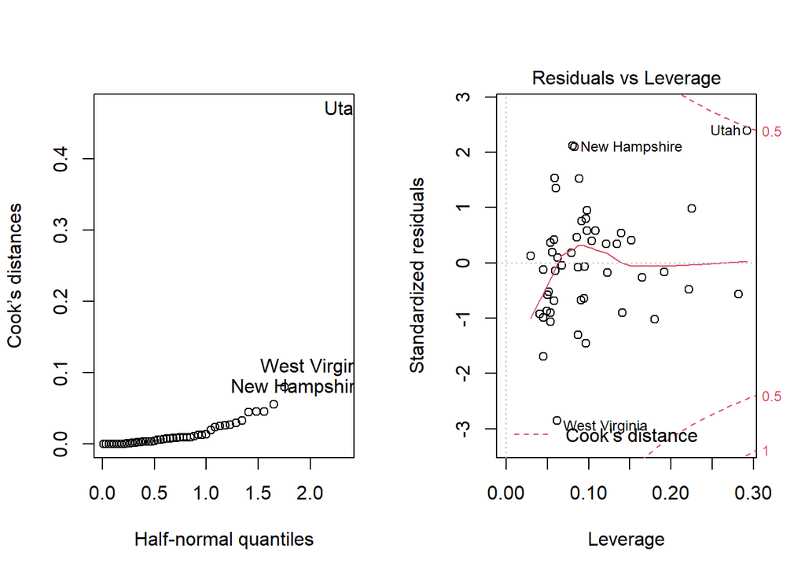

```r
sat_cook <- cooks.distance(sat_lm)

par(mfrow = c(1, 2))
halfnorm(sat_cook, 3, labs = sat_states, ylab="Cook’s distances")
plot(sat_lm, which = 5)
```

Influential point 는 잔차와 leverage가 모두 큰 관측치로, Cooks’s distance를 통해 확인할 수 있는 것처럼 Utah가 가장 큰 Influential point로 확인된다.

모델 개선을 위하여 Utah를 제외한 모형을 적합해보면 다음과 같다.

```r
sat_noUtah <- sat %>%
  rownames_to_column() %>% rename(state = rowname) %>%
  filter(state != "Utah")

sat_lm2 <- lm(total ~ expend + salary + ratio + takers, data = sat_noUtah)

summary(sat_lm2)
```

```
##
## Call:
## lm(formula = total ~ expend + salary + ratio + takers, data = sat_noUtah)
##
## Residuals:
##     Min      1Q  Median      3Q     Max
## -92.118 -18.402   1.808  14.890  67.669
##
## Coefficients:
##              Estimate Std. Error t value Pr(>|t|)
## (Intercept) 1093.8460    53.4226  20.475   <2e-16 ***
## expend        -0.9427    10.1922  -0.092    0.927
## salary         3.0964     2.3283   1.330    0.190
## ratio         -7.6391     3.4279  -2.229    0.031 *
## takers        -2.9308     0.2188 -13.397   <2e-16 ***
## ---
## Signif. codes:  0 '***' 0.001 '**' 0.01 '*' 0.05 '.' 0.1 ' ' 1
##
## Residual standard error: 30.9 on 44 degrees of freedom
## Multiple R-squared:  0.8396, Adjusted R-squared:  0.825
## F-statistic: 57.58 on 4 and 44 DF,  p-value: < 2.2e-16
```

```r
(sat_lm$coefficients - sat_lm2$coefficients) / sat_lm$coefficients
```

```
##  (Intercept)       expend       salary        ratio       takers
## -0.045770306  1.211253663 -0.890467644 -1.107796537 -0.009063192
```

```r
sat[row.names(sat) == "Utah",]
```

```
##      expend ratio salary takers verbal math total
## Utah  3.656  24.3 29.082      4    513  563  1076
```

#### (f) Check the structure of the relationship between the predictors and the response.

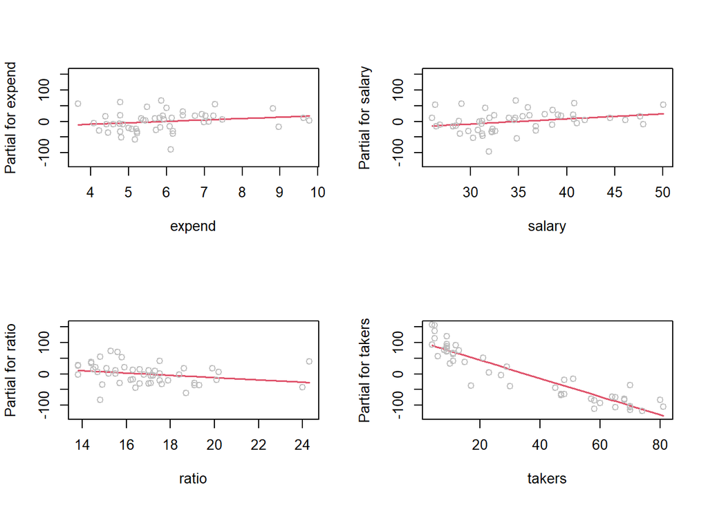

```r
par(mfrow = c(2, 2))
termplot(sat_lm, partial.resid = TRUE)
```

`termplot` 함수를 통해 각 설명변수별로 종속변수와의 관계에 대한 partial residual plot을 작성하였다. `takers`를 제외한 설명변수들의 영향력은 회귀모형의 summary에서 보인 바와 같이 유의하지 않은 것으로 보이며, 산포의 정도에 있어서도 특이할 만한 점은 보이지 않는다.

`takers`는 상대적으로 밀집된 분포와 강한 관계성을 보이고 있다. 또한 40을 기준으로 두개의 그룹으로 구분할 수 있는 것으로 보인다.

```r
# takers >= 40

summary(lm(total ~ expend + salary + ratio + takers,
           data = sat, subset = (takers >= 40)))
```

```
##
## Call:
## lm(formula = total ~ expend + salary + ratio + takers, data = sat,
##     subset = (takers >= 40))
##
## Residuals:
##     Min      1Q  Median      3Q     Max
## -38.434 -15.938  -2.509  11.444  50.289
##
## Coefficients:
##             Estimate Std. Error t value Pr(>|t|)
## (Intercept) 801.4329   105.6773   7.584  5.2e-07 ***
## expend       11.1444    10.8359   1.028    0.317
## salary       -0.6354     2.7190  -0.234    0.818
## ratio         3.9147     4.8627   0.805    0.431
## takers       -0.3003     0.8869  -0.339    0.739
## ---
## Signif. codes:  0 '***' 0.001 '**' 0.01 '*' 0.05 '.' 0.1 ' ' 1
##
## Residual standard error: 23.74 on 18 degrees of freedom
## Multiple R-squared:  0.2627, Adjusted R-squared:  0.09882
## F-statistic: 1.603 on 4 and 18 DF,  p-value: 0.2167
```

```r
# takers < 40

summary(lm(total ~ expend + salary + ratio + takers,
           data = sat, subset = (takers < 40)))
```

```
##
## Call:
## lm(formula = total ~ expend + salary + ratio + takers, data = sat,
##     subset = (takers < 40))
##
## Residuals:
##     Min      1Q  Median      3Q     Max
## -69.155 -16.672   1.747  15.654  54.956
##
## Coefficients:
##             Estimate Std. Error t value Pr(>|t|)
## (Intercept) 993.7178    84.5010  11.760 5.86e-11 ***
## expend        7.7581    16.4329   0.472    0.641
## salary        1.0293     3.3058   0.311    0.758
## ratio         1.4251     4.6111   0.309    0.760
## takers       -5.5242     0.8706  -6.345 2.19e-06 ***
## ---
## Signif. codes:  0 '***' 0.001 '**' 0.01 '*' 0.05 '.' 0.1 ' ' 1
##
## Residual standard error: 30.95 on 22 degrees of freedom
## Multiple R-squared:  0.656,  Adjusted R-squared:  0.5935
## F-statistic: 10.49 on 4 and 22 DF,  p-value: 6.549e-05
```

`takers == 40`을 기준으로 데이터를 분리하여 회귀모형을 적합, summary를 도출한 결과, `takers < 40`에서 모형의 설명력, 유의성이 크게 나타나는 반면, `takers >= 40`에서는 모형의 설명력, 유의성이 크게 떨어지는 것으로 나타난다.

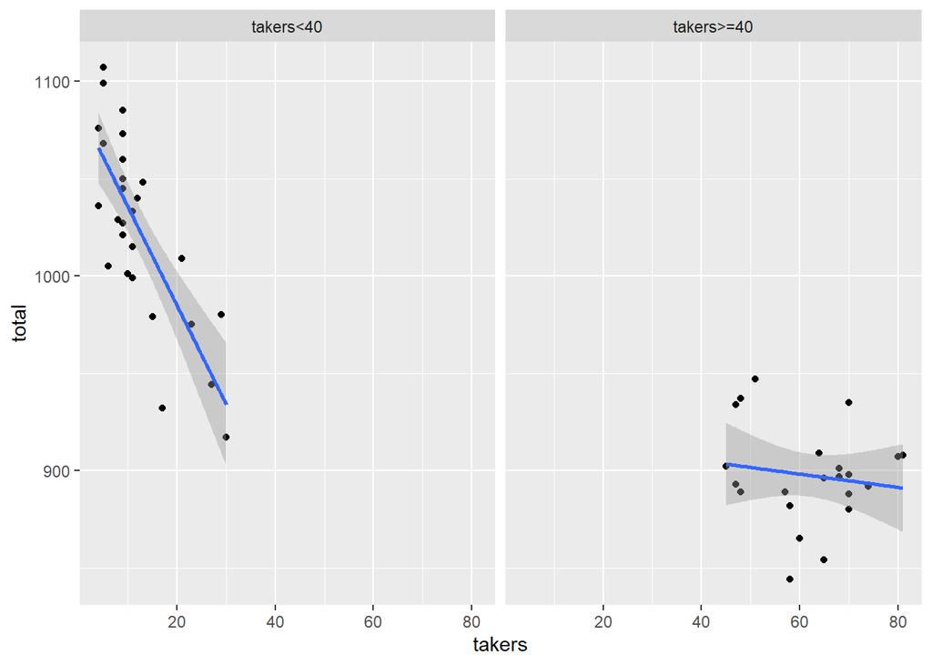

```r
sat_takers <- sat %>%
  mutate(group = ifelse(takers >= 40, "takers>=40", "takers<40"))

ggplot(data = sat_takers, aes(x = takers, y = total)) +
  geom_point() + facet_grid(~ group) + stat_smooth(method = "lm")
```

`takers == 40`을 기준으로 데이터를 분리하여 scatter plot을 작성한 결과에서도, `takers < 40` 에서 `takers`에 따른 `total`의 변화가 강하게 나타남을 확인할 수 있다.

### Problem 2

*For the swiss data, fit a model with Fertility as the response and the other variables as predictors. Answer the questions posed in the first question.*

```r
data("swiss")
head(swiss)
```

```
##              Fertility Agriculture Examination Education Catholic
## Courtelary        80.2        17.0          15        12     9.96
## Delemont          83.1        45.1           6         9    84.84
## Franches-Mnt      92.5        39.7           5         5    93.40
## Moutier           85.8        36.5          12         7    33.77
## Neuveville        76.9        43.5          17        15     5.16
## Porrentruy        76.1        35.3           9         7    90.57
##              Infant.Mortality
## Courtelary               22.2
## Delemont                 22.2
## Franches-Mnt             20.2
## Moutier                  20.3
## Neuveville               20.6
## Porrentruy               26.6
```

```r
str(swiss)
```

```
## 'data.frame':    47 obs. of  6 variables:
##  $ Fertility       : num  80.2 83.1 92.5 85.8 76.9 76.1 83.8 92.4 82.4 82.9 ...
##  $ Agriculture     : num  17 45.1 39.7 36.5 43.5 35.3 70.2 67.8 53.3 45.2 ...
##  $ Examination     : int  15 6 5 12 17 9 16 14 12 16 ...
##  $ Education       : int  12 9 5 7 15 7 7 8 7 13 ...
##  $ Catholic        : num  9.96 84.84 93.4 33.77 5.16 ...
##  $ Infant.Mortality: num  22.2 22.2 20.2 20.3 20.6 26.6 23.6 24.9 21 24.4 ...
```

```r
summary(swiss)
```

```
##    Fertility      Agriculture     Examination      Education
##  Min.   :35.00   Min.   : 1.20   Min.   : 3.00   Min.   : 1.00
##  1st Qu.:64.70   1st Qu.:35.90   1st Qu.:12.00   1st Qu.: 6.00
##  Median :70.40   Median :54.10   Median :16.00   Median : 8.00
##  Mean   :70.14   Mean   :50.66   Mean   :16.49   Mean   :10.98
##  3rd Qu.:78.45   3rd Qu.:67.65   3rd Qu.:22.00   3rd Qu.:12.00
##  Max.   :92.50   Max.   :89.70   Max.   :37.00   Max.   :53.00
##     Catholic       Infant.Mortality
##  Min.   :  2.150   Min.   :10.80
##  1st Qu.:  5.195   1st Qu.:18.15
##  Median : 15.140   Median :20.00
##  Mean   : 41.144   Mean   :19.94
##  3rd Qu.: 93.125   3rd Qu.:21.70
##  Max.   :100.000   Max.   :26.60
```

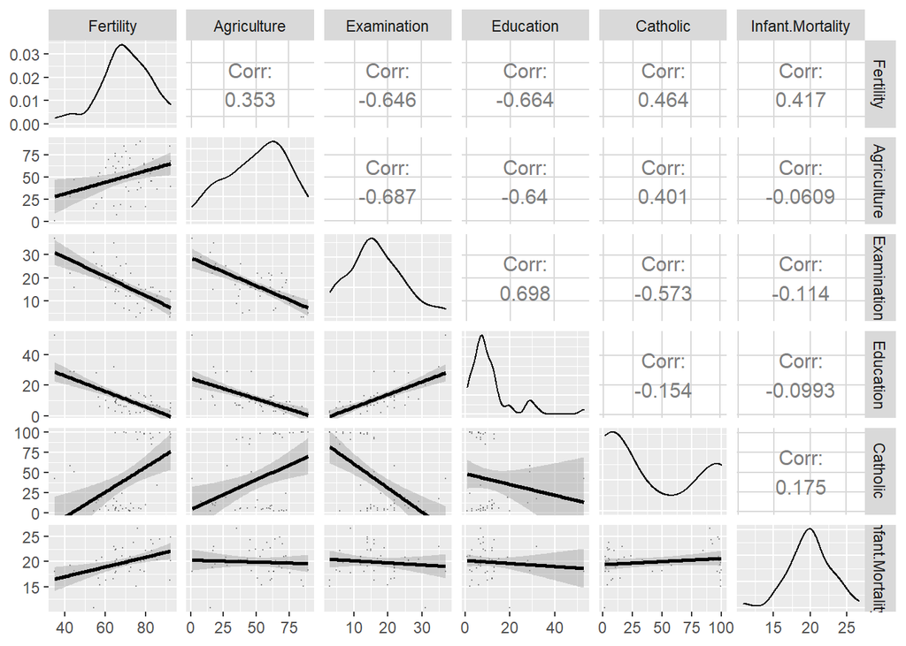

```r
ggpairs(swiss,
        lower = list(continuous = wrap("smooth", alpha = 0.3, size = 0.1)),
        diag = list(discrete="barDiag",
                    continuous = wrap("densityDiag", alpha = 0.5 )),
        upper = list(combo = wrap("box_no_facet", alpha = 0.5),
                            continuous = wrap("cor", size = 4,
                                              alignPercent = 0.8))) +
  theme(legend.position = "bottom")
```

#### Model Fitting

문제에서 요구한 바와 같이 `Fertility`을 종속변수로, 다른 변수를 설명변수로 하여 회귀모형 `sat_lm`을 적합하였다. 전체 모형의 결정계수는 0.71 수준에 p-value는 유의수준 0.05에서 매우 유의하다. 회귀계수의 경우, `Examination`을 제외한 모든 설명변수에서 통계적으로 유의한 것으로 나타난다.

```r
swiss_lm <- lm(Fertility ~ Agriculture + Examination + Education +
                 Catholic + Infant.Mortality, data = swiss)
summary(swiss_lm)
```

```
##
## Call:
## lm(formula = Fertility ~ Agriculture + Examination + Education +
##     Catholic + Infant.Mortality, data = swiss)
##
## Residuals:
##      Min       1Q   Median       3Q      Max
## -15.2743  -5.2617   0.5032   4.1198  15.3213
##
## Coefficients:
##                  Estimate Std. Error t value Pr(>|t|)
## (Intercept)      66.91518   10.70604   6.250 1.91e-07 ***
## Agriculture      -0.17211    0.07030  -2.448  0.01873 *
## Examination      -0.25801    0.25388  -1.016  0.31546
## Education        -0.87094    0.18303  -4.758 2.43e-05 ***
## Catholic          0.10412    0.03526   2.953  0.00519 **
## Infant.Mortality  1.07705    0.38172   2.822  0.00734 **
## ---
## Signif. codes:  0 '***' 0.001 '**' 0.01 '*' 0.05 '.' 0.1 ' ' 1
##
## Residual standard error: 7.165 on 41 degrees of freedom
## Multiple R-squared:  0.7067, Adjusted R-squared:  0.671
## F-statistic: 19.76 on 5 and 41 DF,  p-value: 5.594e-10
```

#### (a) Check the constant variance assumption for the errors.

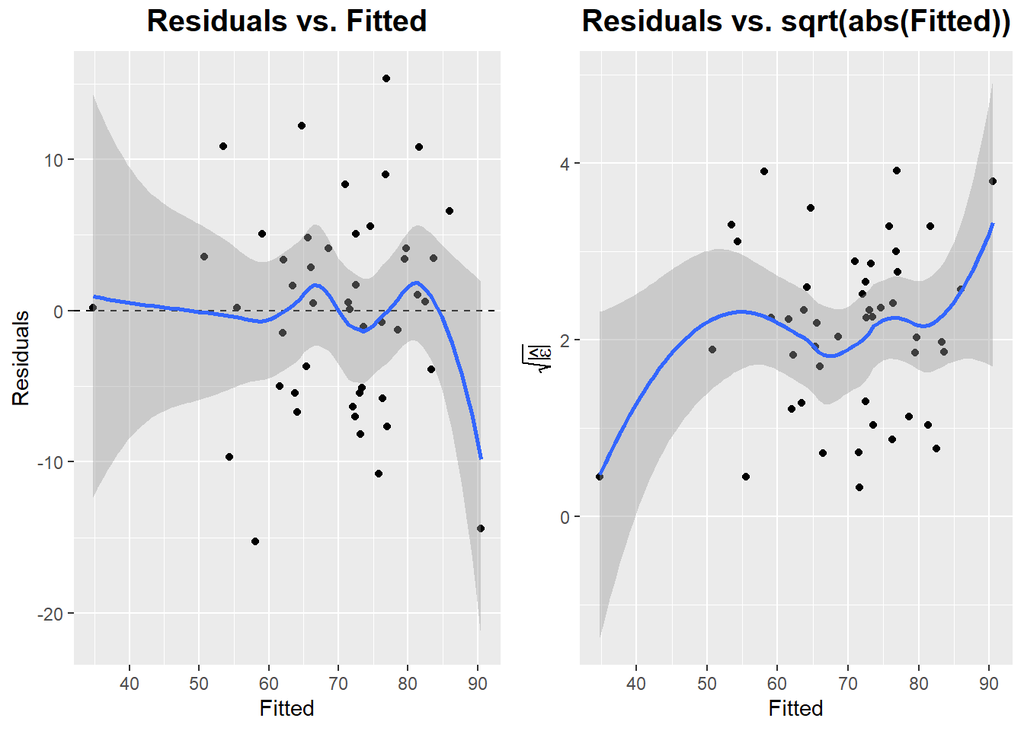

```r
sw_diag1 <- ggplot(data = swiss_lm, aes(x = .fitted, y = .resid)) +
  geom_point() + geom_hline(yintercept = 0, linetype = 2) +
  geom_smooth(method = "loess") +
  xlab("Fitted") + ylab("Residuals") +
  ggtitle(label = "Residuals vs. Fitted") +
  theme(plot.title = element_text(size = 15, hjust = 0.5, vjust = 1.5, face = "bold"))

sw_diag2 <- ggplot(data = swiss_lm, aes(x = .fitted, y = sqrt(abs(.resid)))) +
  geom_point() + geom_smooth(method = "loess") +
  xlab("Fitted") + ylab(expression(sqrt(abs(hat(epsilon))))) +
  ggtitle(label = "Residuals vs. sqrt(abs(Fitted))") +
  theme(plot.title = element_text(size = 15, hjust = 0.5, vjust = 1.5, face = "bold"))

grid.arrange(sw_diag1, sw_diag2, ncol = 2)
```

잔차와 추정치 사이의 관계를 산점도로 표현하여 검토한 결과 및 $\sqrt{|\hat{\epsilon}|}$과 추정치 간의 관계 모두에서 잔차가 매우 고르게 분포하고 있는 것으로 나타나는 바, 등분산성 및 선형성의 가정에 큰 문제가 없는 것으로 관측된다.

```r
summary(lm(abs(residuals(swiss_lm)) ~ fitted(swiss_lm)))
```

```
##
## Call:
## lm(formula = abs(residuals(swiss_lm)) ~ fitted(swiss_lm))
##
## Residuals:
##     Min      1Q  Median      3Q     Max
## -5.2880 -3.4239 -0.3645  1.8645 10.4961
##
## Coefficients:
##                  Estimate Std. Error t value Pr(>|t|)
## (Intercept)       2.16400    4.10172   0.528    0.600
## fitted(swiss_lm)  0.04501    0.05785   0.778    0.441
##
## Residual standard error: 4.12 on 45 degrees of freedom
## Multiple R-squared:  0.01328,    Adjusted R-squared:  -0.008649
## F-statistic: 0.6055 on 1 and 45 DF,  p-value: 0.4405
```

```r
summary(lm(sqrt(abs(residuals(swiss_lm))) ~ fitted(swiss_lm)))
```

```
##
## Call:
## lm(formula = sqrt(abs(residuals(swiss_lm))) ~ fitted(swiss_lm))
##
## Residuals:
##     Min      1Q  Median      3Q     Max
## -1.7992 -0.7539  0.1132  0.5724  1.9678
##
## Coefficients:
##                  Estimate Std. Error t value Pr(>|t|)
## (Intercept)       1.15010    0.94993   1.211    0.232
## fitted(swiss_lm)  0.01361    0.01340   1.016    0.315
##
## Residual standard error: 0.9542 on 45 degrees of freedom
## Multiple R-squared:  0.02242,    Adjusted R-squared:  0.0006947
## F-statistic: 1.032 on 1 and 45 DF,  p-value: 0.3151
```

잔차의 절대값 및 제곱근과 추정치 간의 관계를 분석한 결과에서도, p-value 가 높아 등분산성 가정을 기각할 수 없다.

```r
ncvTest(swiss_lm)
```

```
## Non-constant Variance Score Test
## Variance formula: ~ fitted.values
## Chisquare = 0.3077424, Df = 1, p = 0.57907
```

추가로 `car` 패키지의 `ncvTest` 함수를 통해서도 검토한 결과, p = 0.58 로 나타나는 바 등분산성 가정을 기각할 수 없으며, `swiss` 데이터에는 non-constant variance 이슈가 없는 것으로 판단된다.

#### (b) Check the normality assumption.

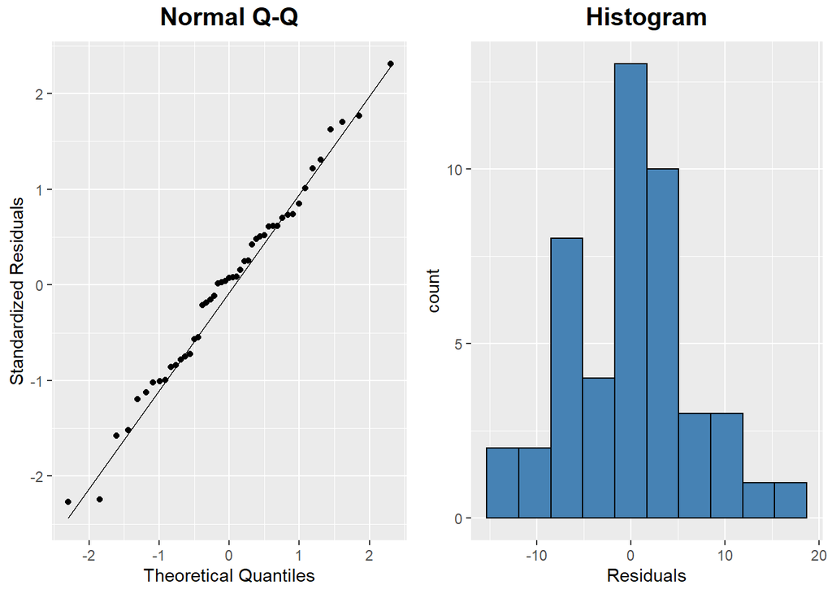

```r
sw_diag3 <- ggplot(data = swiss_lm, aes(sample = .stdresid)) +
  stat_qq() + stat_qq_line() +
  xlab("Theoretical Quantiles") + ylab("Standardized Residuals") +
  ggtitle(label = "Normal Q-Q") +
  theme(plot.title = element_text(size = 15, hjust = 0.5, vjust = 1.5, face = "bold"))

sw_diag4 <- ggplot(data = swiss_lm, aes(x = .resid)) +
  geom_histogram(bins = 10, fill = "steelblue", colour = "black") +
  xlab("Residuals") + ggtitle(label = "Histogram") +
  theme(plot.title = element_text(size = 15, hjust = 0.5, vjust = 1.5, face = "bold"))

grid.arrange(sw_diag3, sw_diag4, ncol = 2)
```

정규성 검토를 위하여 Normal Q-Q plot을 검토한 결과, 거의 직선형태의 분포가 관측되었으며, 직선을 벗어나는 값은 거의 관측되지 않는다. 잔차의 히스토그램 또한 종 형태에 가까운 모양이 관측되며 정규성 가정을 잘 뒷받침하고 있는 것으로 보인다.

```r
shapiro.test(swiss_lm$residuals)
```

```
##
##  Shapiro-Wilk normality test
##
## data:  swiss_lm$residuals
## W = 0.98892, p-value = 0.9318
```

Shapiro-Wilk’s Test 실시 결과 $p-value = 0.93 > 0.05$ 으로, 잔차의 정규성 가정(귀무가설)을 기각하지 못한다.

#### (c) Check for large leverage points.

```r
swiss_hatv <- hatvalues(swiss_lm)
head(swiss_hatv)
```

```
##   Courtelary     Delemont Franches-Mnt      Moutier   Neuveville   Porrentruy
##   0.15681744   0.12258494   0.17368296   0.07961648   0.07219003   0.19833238
```

```r
sum(swiss_hatv)
```

```
## [1] 6
```

`hatvalues`를 통해 leverage를 `swiss_hatv`로 생성하였다. 일반적으로 large leverage는 $2p/n$인 지점을 나타내고, `p = sum(swiss_hatv)` 이므로, 간단히 large leverage point를 추려보면 다음과 같다.

```r
swiss_large <- 2 * sum(swiss_hatv) / length(swiss_lm$fitted.values)

swiss %>%
  rownames_to_column() %>% rename(province = rowname) %>%
  mutate(hatv = hatvalues(swiss_lm)) %>%
  filter(hatv > swiss_large) %>%
  arrange(desc(hatv))
```

```
##       province Fertility Agriculture Examination Education Catholic
## 1 V. De Geneve      35.0         1.2          37        53    42.34
## 2    La Vallee      54.3        15.2          31        20     2.15
##   Infant.Mortality      hatv
## 1             18.0 0.4558363
## 2             10.8 0.3512078
```

위의 2개 주가 large leverage points로 추정된다.

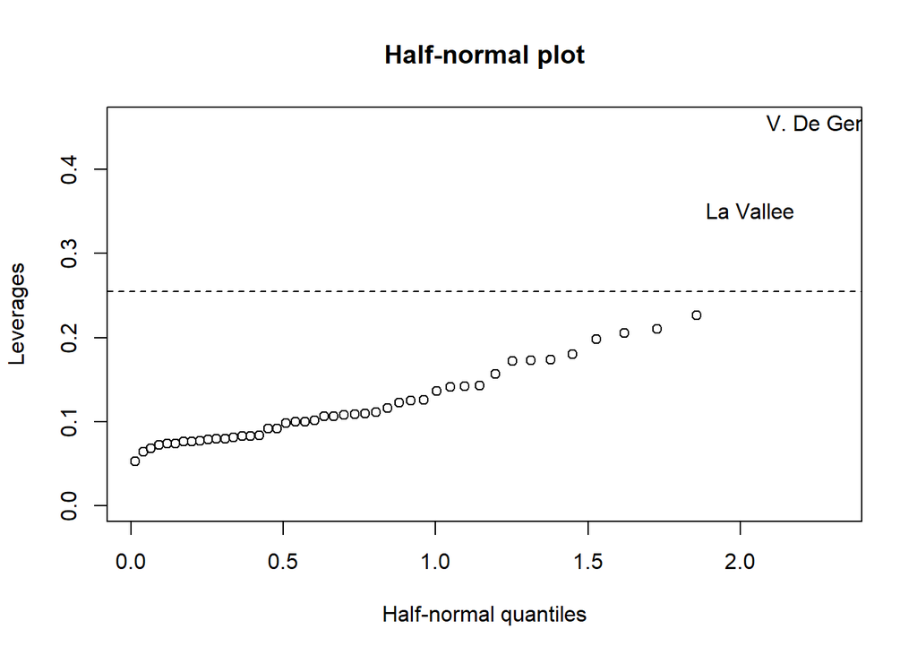

```r
swiss_provinces <- row.names(swiss)
halfnorm(swiss_hatv, labs = swiss_provinces, ylab = "Leverages")
abline(h = (2 * sum(swiss_hatv) / length(swiss_lm$fitted.values)), lty = 2)
title(main = "Half-normal plot")
```

#### (d) Check for outliers.

```r
set.seed(123)
swiss_stud <- rstudent(swiss_lm)

length(swiss_lm$fitted.values)
```

```
## [1] 47
```

```r
swiss_stud2 <- as.data.frame(swiss_stud) %>%
  rownames_to_column() %>% rename(province = rowname) %>%
  rename(stdresid = swiss_stud)
```

Bonferroni correction을 통한 outlier 확인을 위해 스튜던트 잔차를 `swiss_stud2` 라는 데이터프레임으로 생성하였다.

```r
swiss_stud2 %>% arrange(stdresid) %>% head(3)
```

```
##      province  stdresid
## 1 Rive Gauche -2.394471
## 2  Porrentruy -2.367218
## 3      Moudon -1.604183
```

```r
swiss_stud2 %>% arrange(stdresid) %>% tail(3)
```

```
##      province stdresid
## 45  Neuchatel 1.745412
## 46 Neuveville 1.816142
## 47     Sierre 2.445227
```

```r
#Bonferroni critical value
swiss_bcv <- qt(0.05 / (47*2), 40)
swiss_bcv
```

```
## [1] -3.529468
```

```r
swiss_stud2 %>% filter(abs(stdresid) > abs(swiss_bcv))
```

```
## [1] province stdresid
## <0 rows> (or 0-length row.names)
```

유의수준 0.05, 자유도 40 (47 - 변수 6 - 1 = 40) 기준으로 계산한 결과 에서 Bonferroni critical value = -3.53이며, 절대값을 통해 양측에서 outlier를 확인한 결과, 해당하는 outlier가 없음을 확인할 수 있다.

#### (e) Check for influential points.

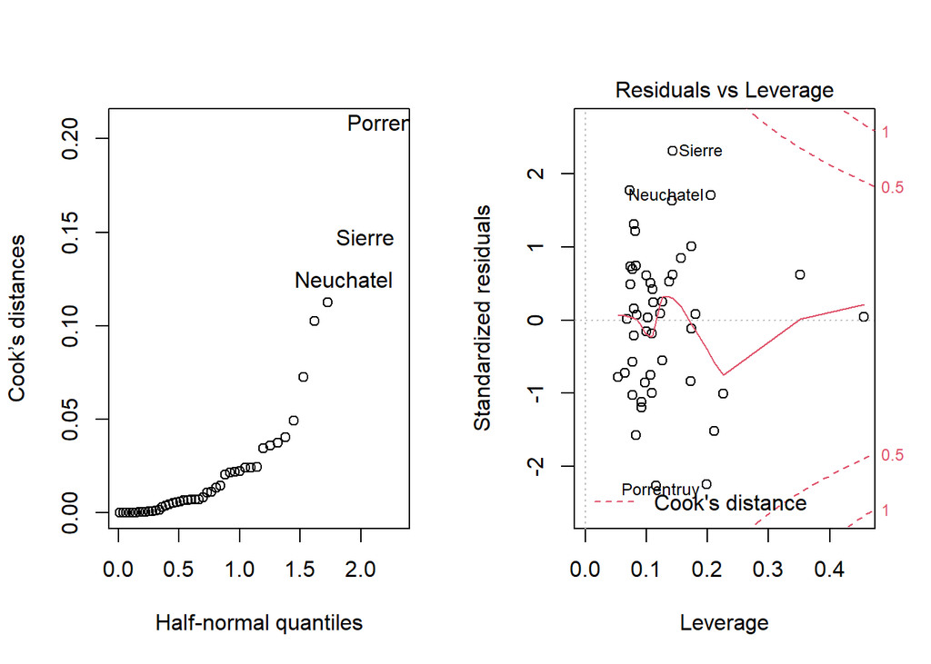

```r
swiss_cook <- cooks.distance(swiss_lm)

par(mfrow = c(1, 2))
halfnorm(swiss_cook, 3, labs = swiss_provinces, ylab="Cook’s distances")
plot(swiss_lm, which = 5)
```

Influential point 는 잔차와 leverage가 모두 큰 관측치로, Cook’s distance를 통해 확인할 수 있는 것처럼 Porrentruy가 가장 큰 Influential point로 확인되나, Cook’s distance가 0.5 미만이다.

모델 개선 여부 확인을 위하여 Porrentruy를 제외한 모형을 적합해보면 다음과 같다.

```r
swiss_noPor <- swiss %>%
  rownames_to_column() %>% rename(province = rowname) %>%
  filter(province != "Porrentruy")

swiss_lm2 <- lm(Fertility ~ Agriculture + Examination + Education +
                  Catholic + Infant.Mortality, data = swiss_noPor)

summary(swiss_lm2)
```

```
##
## Call:
## lm(formula = Fertility ~ Agriculture + Examination + Education +
##     Catholic + Infant.Mortality, data = swiss_noPor)
##
## Residuals:
##      Min       1Q   Median       3Q      Max
## -15.7365  -5.0540   0.1953   4.1084  15.5399
##
## Coefficients:
##                  Estimate Std. Error t value Pr(>|t|)
## (Intercept)      65.45554   10.16998   6.436 1.15e-07 ***
## Agriculture      -0.21034    0.06859  -3.067  0.00387 **
## Examination      -0.32278    0.24227  -1.332  0.19031
## Education        -0.89506    0.17384  -5.149 7.36e-06 ***
## Catholic          0.11269    0.03363   3.351  0.00177 **
## Infant.Mortality  1.31567    0.37571   3.502  0.00115 **
## ---
## Signif. codes:  0 '***' 0.001 '**' 0.01 '*' 0.05 '.' 0.1 ' ' 1
##
## Residual standard error: 6.794 on 40 degrees of freedom
## Multiple R-squared:  0.7415, Adjusted R-squared:  0.7091
## F-statistic: 22.94 on 5 and 40 DF,  p-value: 8.583e-11
```

```r
(swiss_lm$coefficients - swiss_lm2$coefficients) / swiss_lm$coefficients
```

```
##      (Intercept)      Agriculture      Examination        Education
##       0.02181330      -0.22211255      -0.25102845      -0.02769452
##         Catholic Infant.Mortality
##      -0.08231754      -0.22154724
```

```r
swiss[row.names(swiss) == "Porrentruy",]
```

```
##            Fertility Agriculture Examination Education Catholic
## Porrentruy      76.1        35.3           9         7    90.57
##            Infant.Mortality
## Porrentruy             26.6
```

#### (f) Check the structure of the relationship between the predictors and the response.

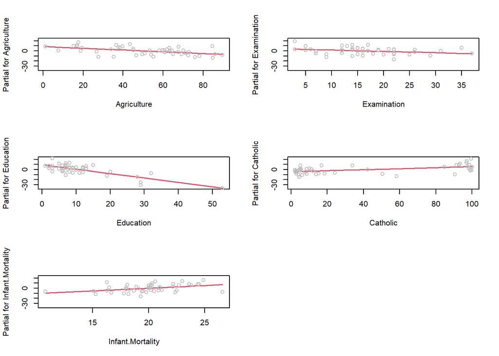

```r
par(mfrow = c(3, 2))
termplot(swiss_lm, partial.resid = TRUE)
```

`termplot` 함수를 통해 각 설명변수별로 종속변수와의 관계에 대한 partial residual plot을 작성하였다. `Examination`을 제외한 설명변수들이 모두 앞서 살펴본 바와 같이 관계에 영향력을 가지고 유의함을 확인할 수 있다.

한편, `Catholic`의 경우 60을 기준으로 두개의 그룹으로 구분할 수 있는 것으로 보인다.

```r
# Catholic >= 60

summary(lm(Fertility ~ Agriculture + Examination + Education +
             Catholic + Infant.Mortality, data = swiss, subset = (Catholic >= 60)))
```

```
##
## Call:
## lm(formula = Fertility ~ Agriculture + Examination + Education +
##     Catholic + Infant.Mortality, data = swiss, subset = (Catholic >=
##     60))
##
## Residuals:
##      Min       1Q   Median       3Q      Max
## -10.2801  -4.3747  -0.4216   3.9807  14.9933
##
## Coefficients:
##                  Estimate Std. Error t value Pr(>|t|)
## (Intercept)      128.9720   109.7559   1.175    0.267
## Agriculture       -0.2002     0.2452  -0.817    0.433
## Examination        0.6356     1.1732   0.542    0.600
## Education         -1.2951     1.3355  -0.970    0.355
## Catholic          -0.2986     1.0061  -0.297    0.773
## Infant.Mortality  -0.1929     1.4966  -0.129    0.900
##
## Residual standard error: 8.964 on 10 degrees of freedom
## Multiple R-squared:  0.2091, Adjusted R-squared:  -0.1863
## F-statistic: 0.5289 on 5 and 10 DF,  p-value: 0.7502
```

```r
# Catholic < 60

summary(lm(Fertility ~ Agriculture + Examination + Education +
             Catholic + Infant.Mortality, data = swiss, subset = (Catholic < 60)))
```

```
##
## Call:
## lm(formula = Fertility ~ Agriculture + Examination + Education +
##     Catholic + Infant.Mortality, data = swiss, subset = (Catholic <
##     60))
##
## Residuals:
##      Min       1Q   Median       3Q      Max
## -11.0880  -3.7290  -0.7957   3.3144  15.6641
##
## Coefficients:
##                  Estimate Std. Error t value Pr(>|t|)
## (Intercept)      69.28042   11.79454   5.874 3.97e-06 ***
## Agriculture      -0.21970    0.07049  -3.117  0.00455 **
## Examination      -0.49787    0.25861  -1.925  0.06566 .
## Education        -0.53880    0.19044  -2.829  0.00906 **
## Catholic         -0.21234    0.10512  -2.020  0.05423 .
## Infant.Mortality  1.27050    0.42439   2.994  0.00613 **
## ---
## Signif. codes:  0 '***' 0.001 '**' 0.01 '*' 0.05 '.' 0.1 ' ' 1
##
## Residual standard error: 5.909 on 25 degrees of freedom
## Multiple R-squared:  0.7531, Adjusted R-squared:  0.7037
## F-statistic: 15.25 on 5 and 25 DF,  p-value: 6.637e-07
```

`Catholic == 60`을 기준으로 데이터를 분리하여 회귀모형을 적합, summary를 도출한 결과, `Catholic < 60`에서 모형의 설명력, 유의성이 크게 나타나는 반면, `Catholic >= 60`에서는 모형의 설명력, 유의성이 크게 떨어지는 것으로 나타난다.

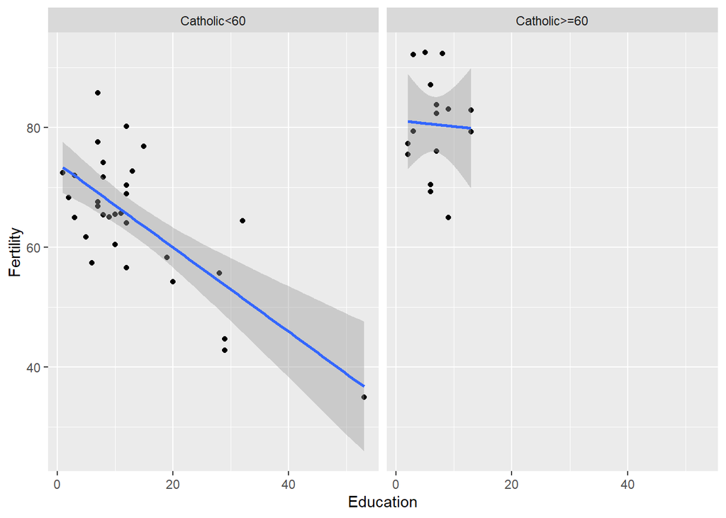

```r
swiss_cath <- swiss %>%
  mutate(group = ifelse(Catholic >= 60, "Catholic>=60", "Catholic<60"))

ggplot(data = swiss_cath, aes(x = Education, y = Fertility)) +
  geom_point() + facet_grid(~ group) + stat_smooth(method = "lm")
```

`Catholic == 60`을 기준으로 데이터를 분리하여 scatter plot을 작성한 결과에서도, `Catholic < 60` 에서 `Education`에 따른 `Fertility`의 변화가 강하게 나타나는 등, 그룹의 분류에 따른 차이를 확인할 수 있어 그룹별 분석을 수행하는 것도 모델을 개선하는 데 도움이 될 수 있을 것으로 판단된다.